FPCC02 Teste de Hipóteses Tiago Clementino 28 de maio de 2018

# Objetivo

Vamos reproduzir um problema de exploração de dados que a Fundação Wikimedia usou em 2016 no recrutamento de pessoas para trabalhar em seu departamento de descoberta. O objetivo é seguir as instruções colocadas na tarefa original. Aqui devemos revisitar duas das questões respondidas no *checkpoint* 1 deste laboratório.

O objetivo é explorar as possibilidades da inferência estatística por teste de hipóteses. A entrega consiste de um relatório explorando por este método estatístico duas das perguntas do último relatório. Escolhemos a pergunta 1 (**Q1**) e a variação da pergunta um com uma população artificial gerada randomicamente a partir do grupo “a”.

### Contexto

O departamento de descoberta da Fundação Wikimedia utiliza um registro de eventos (Event Logging, EL) para avaliar várias métricas de performance e usabilidade, ajudando-os a tomar decisões. Sobretudo, tal iniciativa está interessada em:

- *clickthrough rate*: a proporção de sessões de busca onde o usuário clica em um dos resultados apresentados.
- *zero results rate*: a proporção de buscas que não tiveram resultados.

e outras métricas fora do escopo desta tarefa. EL usa Javascript para enviar mensagens aos servidores da Wikimedia de forma assíncrona quando o usuário realiza ações específicas. Nesta tarefa irei analisar uma amostra deste registro de eventos na intenção de tirar conclusões a respeito de todo o registro de eventos.

### Dados

O conjunto de dados vem de uma estratégia de EL usada para avaliar a satisfação do usuário. Usuários *standalone* são randomicamente coletados para ser anonimamente rastreados por tal estratégia, que usa um sistema de descoberta do tipo *I’m alive* para estimar quanto tempo os usuários permanecem nas páginas que eles visitam. O conjunto de dados contém em tabela pouco mais de uma semana de EL com as seguintes colunas.

| Campo | Tipo | Descrição |
| --- | --- | --- |
| `uuid` | string | Identificador universal único (UUID) para gerenciamento dos registros. |
| `timestamp` | integer | Data e hora (UTC) do evento com a seguinte formatação: YYYYMMDDhhmmss. |
| `session_id` | string | Um identificador individual de sessão único. |
| `group` | string | Uma marca (“a” ou “b”). |
| `action` | string | Identifica a natureza do evento em que foi criado. Veja abaixo. |
| `checkin` | integer | Quantos segundos a página passou aberta. |
| `page_id` | string | Um identificador único relacionado às páginas visitadas e verificadas. |
| `n_results` | integer | Número de sugestões de páginas retornado. Apenas para eventos searchResultPage. |
| `result_position` | integer | A posição do link na SERP (Search Engine Results Page) para a página visitada. |

O campo `action` pode ter os seguintes valores:

- `searchResultPage`: quando uma nova busca é realizada e uma SERP é apresentado ao usuário.
- `visitPage`: quando o usuário clica em um *link* dos resultados.
- `checkin`: quando o usuário permaneceu em uma página por um intervalo de tempo pré-definido.

### Descrição do objetivo

O objetivo aqui é criar um relatório reproduzível respondendo por teste de hipóteses, de acordo com os dados, as seguintes perguntas:

- **Q1**. Qual é a *clickthrough rate* geral diária? Como isto varia entre os grupos?
- **Q1.alternativa**. Responda **Q1** novamente, porém utilize apenas o grupo A, o dividindo randomicamente em dois grupos A e A’.

*As questão **Q2**,**Q3** e **Q4** descrita na tarefa da Wikimedia foge ao escopo deste relatório.

### Dados tratados

Para Facilitar nosso esforço em resolver as duas questões, tratei os dados utilizando o script “import-events_to_searches.R” (editado a partir da versão inicial presente no repositório original do *lab 02 checkpoint 04*). As informações que antes eram referentes a eventos pontuais, agora foram agrupadas em buscas (com possivelmente mais de um evento). Os novos dados, agora simplificados e mais fáceis de tratar, estão dispostos em uma tabela com as seguintes colunas:

| Campo | Tipo | Descrição |
| --- | --- | --- |
| `search_index` | integer | Um contator que marca cada uma das buscas em uma sessão |
| `session_start_timestamp` | integer | Data e hora de início da sessão correspondente |
| `day` | date | Data da sessão correspondente |
| `session_legth` | integer | Duração da sessão contada em segundos |
| `last_search` | integer | Última busca realizada na sessão (último `search_index`) |
| `group` | string | Uma marca de grupo (“a” e “b”) |
| `results` | integer | Número de resultados da busca |
| `num_clicks` | integer | Número de páginas acessadas na busca |
| `first_click` | integer | Posição do primeiro click |

# Questões

### Q1. Qual é a *clickthrough rate* geral diária? Como isto varia entre os grupos?

Antes de começarmos devemos estabelecer o que é a taxa de clicks geral diária. Em meu entendimento, cada sessão tem uma finalidade específica e qualquer busca será realização em função deste fim. Buscas de fato vazias são aquelas em que o usuário não encontrou o que procura em toda a sua sessão. Diante deste entendimento, tome a *clickthrough rate* como a taxa de cliques por sessão. Como a taxa é por sessão, agrupar os dados desta forma é um bom primeiro passo. Enquanto ocorre este agrupamento criei uma nova variável que ajuda na tarefa de analisar a taxa de cliques: `visited` para identificar facilmente qual sessão teve ou não cliques (1 ou 0). `results` e `num_clicks` somam as variáveis originais de mesmo nome, agrupando por sessão.

```r
sessions = buscas %>% #agrupando por sessão
    group_by(group, day, session_id) %>%
    summarise(visited = ifelse(sum(num_clicks) > 0, 1.0, 0.0),
              session_legth = first(session_legth),
              last_search = first(last_search),
              results = sum(results, na.rm = TRUE),
              num_clicks = sum(num_clicks, na.rm = TRUE),
              first_search_zero = ifelse(first(results)==0, "Sim", "Não"))
```

Partindo para o problema em si, espero ser possível estimar a relação da *clickthrough rate* diária entre os grupos “a” e “b”. Para tanto, em alternativa ao que foi feito no [relatório anterior](http://rpubs.com/tiago_clementino/390167), que fez uso de IC com bootstrap, utilizarei testes de hipóteses com permutação.

A seguir vou relembrar a distribuição da variável em questão (*clickthrough rate*) diariamente e em função dos grupos. Veja o gráfico.

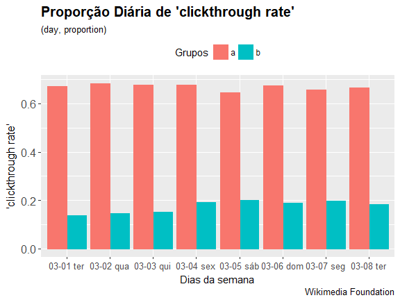

```r
sessions %>%
    group_by(group, day) %>%
    arrange(day) %>%
    summarise(proportion = mean(visited)) %>%
        ggplot(aes(x = format(day, "%m-%d %a"), y = proportion, color = group, fill=group)) +
        geom_col(position = "dodge") +
    labs(x='Dias da semana',
        y="'clickthrough rate'",
        title="Proporção Diária de 'clickthrough rate'",
        color='Grupos',
        fill='Grupos',
        subtitle="(day, proportion)",
        caption="Wikimedia Foundation") +
    theme(plot.title = element_text(face="bold",size = "15"),
        plot.subtitle = element_text(size = "10"),
        plot.caption = element_text(size="10"),
        axis.title.y = element_text(size="12"),
        axis.text.x = element_text(size="10"),
        axis.text.y = element_text(size="12"),
        legend.position="top",
        panel.border=element_blank())
```

Perceba que há duas regiões de valores claramente distintas, tendo o grupo “a” uma taxa nitidamente mais elevada que o grupo “b”, e isto irá refletir nos próximos passos.

Utilizaremos a partir de agora uma metodologia de teste de hipóteses com permutação em duas caldas sobre nossa amostra. O objetivo é realizar uma análise pareada, tendo como estatística a diferença entre as médias de cliques diárias de “a” e “b”, os grupos de comparação. Antes de tudo, devemos estabelecer nossas hipóteses e o que significam especificamente:

- **H0**: Sendo esta a hipótese nula, significa que não há correlação/diferença entre os grupos. Caso seja aceita, qualquer comportamento apresentado será consequência da natureza geral dos dados. Para tanto, a distribuição da diferença entre as médias de cliques de cada grupo deve incluir o zero.
- **H1**: Sendo a hipótese alternativa. Caso seja verificada, significa que há correlação entre os grupos. A verificação desta hipótese é feita através da distância em relação à **H0**.

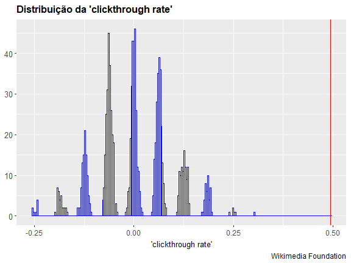

```r
populacao_1 <- sessions %>%
    group_by(day, group) %>%
    summarise(ctr = sum(visited)/n()) %>%
    permutationTest2(mean(ctr), treatment = group, R=999)

tibble(observed = as.double(populacao_1$observed), statistic = as.double(populacao_1$replicates)) %>%
  ggplot(aes(x = statistic)) +
  geom_histogram(binwidth = .003, fill = "white", color="blue") +
    geom_vline(xintercept=populacao_1$observed, color="red")+
    labs(x="'clickthrough rate'",
        y=NULL,
        title="Distribuição da 'clickthrough rate'",
        caption="Wikimedia Foundation") +
    theme(plot.title = element_text(face="bold",size = "12"),
        plot.caption = element_text(size="9"),
        axis.title.x = element_text(size="10"),
        axis.text.x = element_text(size="9"),
        axis.text.y = element_text(size="10"),
        panel.border=element_blank())
```

Vejamos nos dados abaixo que, como percebemos no gráfico acima, podemos concluir que há uma correlação da taxa de cliques entre os dois grupos. Vejamos: Perceba que **Observed**, sendo a média da taxa de cliques diária na nossa amostra, está longe de **Mean**, o ponto central da distribuição gerada pelas permutações (**H0**), rejeitando a hipótese nula. Veja também que **Mean** é um valor bem próximo de zero, e não poderia ser diferente, pois **H0** prevê ausência da correlação entre as taxas de “a” e “b”.

Sendo assim, com base nestes valores, com um grau de significância estatística maior que 95% (p-valor menor que 0.005), podemos afirmar que há uma correlação significativa entre estes valores na população (refletida na amostra), rejeitando **H0**.

Relembrando o [relatório](http://rpubs.com/tiago_clementino/390167) anterior, podemos comparar IC(Intervalos de Confiança) e TH (Testes de Hipóteses). Entenda que TH não traz nenhuma informação numérica acerca dos dados da população, apenas responde uma pergunta sobre ela. Já IC, além de cumprir a mesma função de responder à uma pergunta sobre a população, ainda apresenta informação numérica sobre esta, deixando o pesquisador à vontade para decidir se aqueles valores o permitem concluir alguma coisa.

```
## Call:
## permutationTest2(data = ., statistic = mean(ctr), treatment = group,
##     R = 999)
## Replications: 999
## Two samples, sample sizes are 8 8
##
## Summary Statistics for the difference between samples 1 and 2:
##                 Observed        Mean Alternative PValue
## mean(ctr): a-b 0.4941402 0.001657691   two.sided  0.002
```

Para finalizar, perceba no gráfico de dispersão abaixo a distância entre os valores de `clickthrough rate` na amostra para cada dia e das permutações realizadas durante o teste de hipótese também em cada dia separadamente. Veja que há uma distância nítida entre os pontos como verificamos no teste.

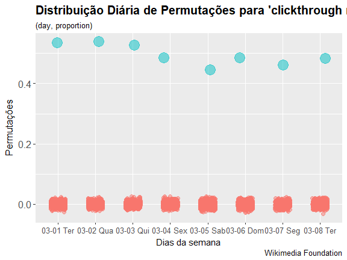

```r
populacao_1 %>%
    group_by(day) %>%
    arrange(day) %>%
    ggplot(aes(x = day, y = estatistica, color = observed, size = observed)) +
    geom_jitter(height = .0, width = .2, alpha = 0.5) +
    labs(x='Dias da semana',
        y="Permutações",
        title="Distribuição Diária de Permutações para 'clickthrough rate'",
        color='Grupos',
        fill='Grupos',
        subtitle="(day, proportion)",
        caption="Wikimedia Foundation") +
    theme(plot.title = element_text(face="bold",size = "15"),
        plot.subtitle = element_text(size = "10"),
        plot.caption = element_text(size="10"),
        axis.title.y = element_text(size="12"),
        axis.text.x = element_text(size="10"),
        axis.text.y = element_text(size="12"),
        legend.position="none",
        panel.border=element_blank())
```

### Q1.alternativa. Teste o que acontece se para Q1, em vez de comparar o grupo A com o grupo B (um teste A/B), você compara metade das sessões do grupo A (escolhida aleatoriamente) com outra metade das sessões do mesmo grupo (um teste A/A).

Relembrando **Q1**: “Qual é a *clickthrough rate* geral diária? Como isto varia entre os grupos?”. Agora os grupos em questão são A e A’, gerados aleatoriamente a partir do grupo “a”.

Sob estas circunstâncias, tal como pudemos ver no [relatório anterior](http://rpubs.com/tiago_clementino/390167) a única resposta correta que poderíamos concluir seria que não se pode concluir que há alguma diferença entre estes dois grupos (selecionados aleatoriamente). Vejamos se isto se confirma.

Refazendo o processo realizado em **Q1**, devemos estabelecer nossas hipóteses e o que significam especificamente:

- **H0**: Sendo esta a hipótese nula, significa que não há correlação/diferença entre os grupos. Caso esteja aceita, qualquer resultado apresentado será consequência da natureza geral dos dados. Sendo assim, a distribuição da diferença entre as médias de cliques deve incluir o zero.
- **H1**: Sendo a hipótese alternativa. Caso seja aceita, então há correlação entre os grupos. A verificação desta hipótese é feita através da distância em relação à **H0**.

```r
sessionsA <- sessions %>% filter(group == "a",!is.na(visited))

sessionsA_ = sample_n(sessionsA, 2104) %>% mutate(group_ = "A'")

sessionsA = sample_n(sessionsA, 2104) %>% mutate(group_ = "A")

populacao_AA_ = bind_rows(sessionsA_, sessionsA)
```

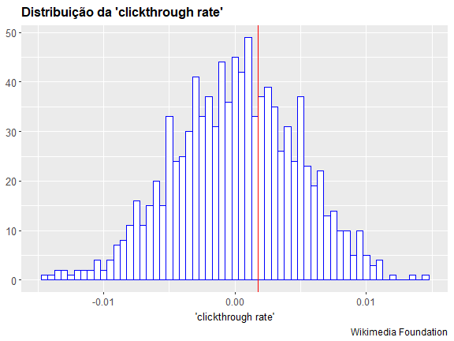

```r
populacao_AA <- populacao_AA_ %>%
    group_by(day, group_) %>%
    summarise(ctr = sum(visited)/n()) %>%
    permutationTest2(mean(ctr), treatment = group_, R=999)

tibble(observed = as.double(populacao_AA$observed), statistic = as.double(populacao_AA$replicates)) %>%
  ggplot(aes(x = statistic)) +
  geom_histogram(binwidth = .0005, fill = "white", color="blue") +
    geom_vline(xintercept=populacao_AA$observed, color="red")+
    labs(x="'clickthrough rate'",
        y=NULL,
        title="Distribuição da 'clickthrough rate'",
        caption="Wikimedia Foundation") +
    theme(plot.title = element_text(face="bold",size = "12"),
        plot.caption = element_text(size="9"),
        axis.title.x = element_text(size="10"),
        axis.text.x = element_text(size="9"),
        axis.text.y = element_text(size="10"),
        panel.border=element_blank())
```

Vejamos nos dados abaixo que, como percebemos no gráfico acima, não há uma correlação da taxa de cliques entre os dois grupos. Novamente: Perceba que **Observed**, sendo a média da taxa de cliques diária na nossa amostra, é similar à **Mean** e ambas estão próximas a zero, tendendo à aceitar a hipótese nula e sugerindo a ausência da diferença entre as taxas de “A” e “A’”.

Novamente, a partir de teste de hipóteses, não temos dados numéricos que materializem nossos resultados, apenas a resposta a uma pergunta com base em um único valor (o centro da distribuição) e sua significância, ao contrário da inferência estatística por IC que apresenta uma faixa de valores possíveis (intervalo) e a significância.

```
## Call:
## permutationTest2(data = ., statistic = mean(ctr), treatment = group_,
##     R = 999)
## Replications: 999
## Two samples, sample sizes are 8 8
##
## Summary Statistics for the difference between samples 1 and 2:
##                    Observed         Mean Alternative PValue
## mean(ctr): A-A' 0.001722909 0.0001143016   two.sided  0.752
```

Novamente, para finalizar, perceba no gráfico de dispersão abaixo a distância entre os valores de `clickthrough rate` na amostra para cada dia e das permutações realizadas durante o teste de hipótese também em cada dia separadamente. Não há distinção entre suas posições.

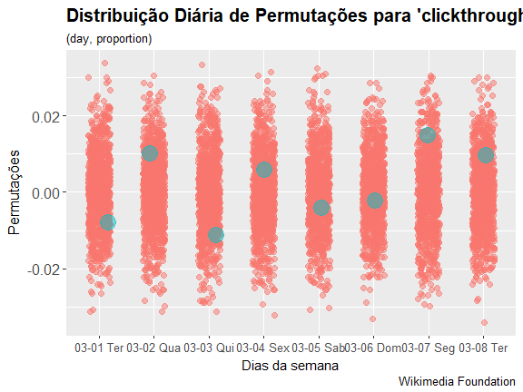

```r
populacao_AA %>%
    group_by(day) %>%
    arrange(day) %>%
    ggplot(aes(x = day, y = estatistica, color = observed, size = observed)) +
    geom_jitter(height = .0, width = .2, alpha = 0.5) +
    labs(x='Dias da semana',
        y="Permutações",
        title="Distribuição Diária de Permutações para 'clickthrough rate'",
        color='Grupos',
        fill='Grupos',
        subtitle="(day, proportion)",
        caption="Wikimedia Foundation") +
    theme(plot.title = element_text(face="bold",size = "15"),
        plot.subtitle = element_text(size = "10"),
        plot.caption = element_text(size="10"),
        axis.title.y = element_text(size="12"),
        axis.text.x = element_text(size="10"),
        axis.text.y = element_text(size="12"),
        legend.position="nome",
        panel.border=element_blank())
```

# Sumário

A partir das duas questões propostas analisamos o comportamento da variável `clickthrough rate` diariamente, mas, principalmente, exploramos as possibilidades do método de inferência estatística por teste de hipóteses. Com base em **Q1** e o cálculo das sessões de buscas com acesso a resultados (cliques) pudemos inferir, com base na amostra, uma diferença significativa nas proporções entre os grupos “a” e “b”, o que sugere uma diferença funcional entre estas duas categorias.

Por fim, refazendo a **Q1** (alternativa), agora em uma análise não-pareado a partir de uma reamostragem aleatória da amostra original (criando os grupos A e A’), pudemos confirmar a eficácia do método de teste de hipóteses, pois, diferentemente do caso anterior, uma diferença entre os grupos não foi verificada.